# Lecture 12: Scatterplots

Nick Huntington-Klein

18 May, 2020

## Scatterplots

- Scatterplots are a very tricky kind of graph to get right
- They’re the purest way to show the relationship between two continuous variables
- But they can get hard to read, messy, obtuse
- And readers can be led astray!

## Scatterplots

- Scatterplots show the relationship between two variables
- By simply plotting every observation
- The shape of the relationship between them (positive, negative, null, U-shaped, etc.) should be clear
- Use when that’s your goal, explaining how two variables move together
- Can also be handy for pointing out outliers

## Scatterplots and Audience

- One thing to keep in mind is that scatterplots require a bit more *data sense* to intrepret than most graphs
- You need to be fairly familiar with data and how it moves to really understand a scatterplot at a glance
- So be careful with your audience when making a scatterplot
- For a lay audience, a scatterplot can’t be the least bit ambiguous
- For a more advanced audience there can be more complexity

## Aesthetics

- How can we draw focus with scatterplots (and what stories get told)?
- Color, size, shape
- Select colors to tell a story (bad = red/good = blue perhaps)
- Data labels (or just text points)
- Opacity
- Lines and encirclings
- Callouts

## Color, size, shape, and opacity

- Basically, there are plenty of ways to decorate the dots
- But if they have to check a big ol’ legend what’s the point
- Also be aware, shape can be hard to distinguish
- Try to make the designations mean something!
- If different color and shape overlap a lot, they can be hard to tell apart

## Color and Shape

What’s good and bad about this graph?

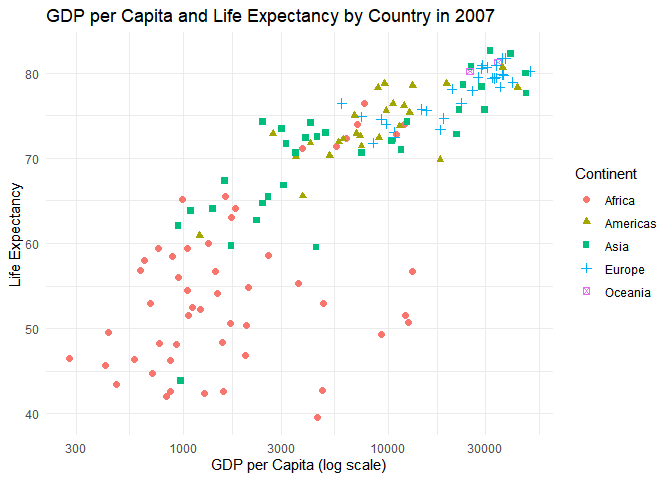

## Size

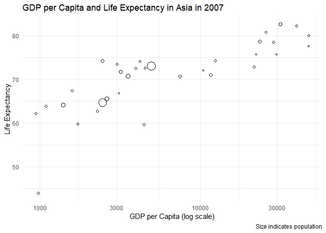

## Size

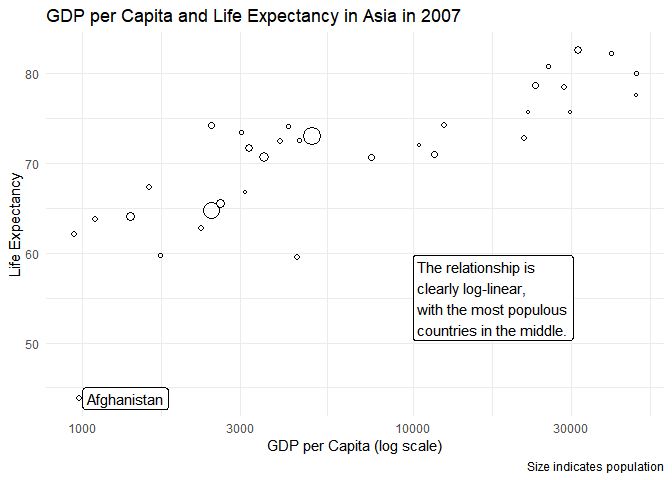

## Opacity

How else can we make Asia pop if we’re trying to focus on it?

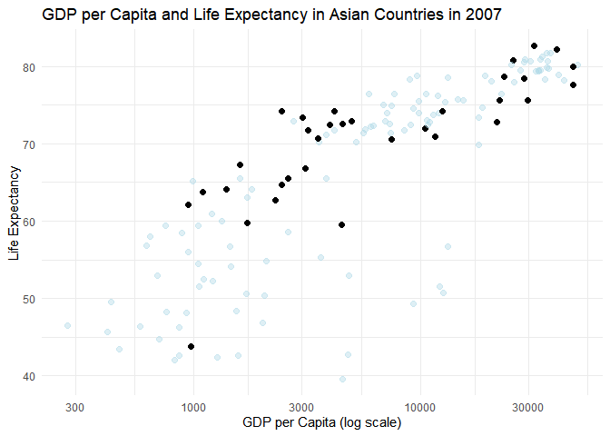

## Data Labels

- We already showed with Afghanistan how we can use data labels to draw attention to certain points
- Good if we want to focus on one for the story, or if we want to explain an odd observation like Afghanistan
- We could just replace the points with text! (`geom_text` or `geom_text_repel` or similarly with labels)
- This can get messy REAL fast but can be highly informative
- Only use if the number of observations is tiny.

## Data Labels

It takes a special scenario for this to be right! This graph doesn’t give us much.

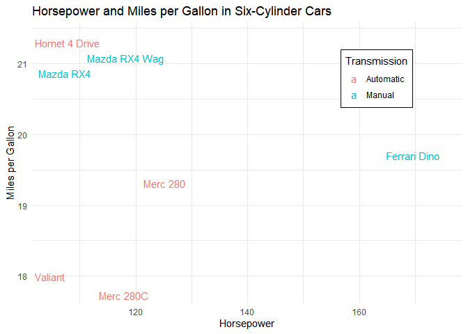

## Lines and Encirclings

- In scatterplots, lines generally help partition data
- Above/below in either direction, relative to some real cutoff
- Encirclings (`geom_encircle` in **ggalt**) can be good ways of setting apart observations in a clearer way than color

## Lines and Encirclings

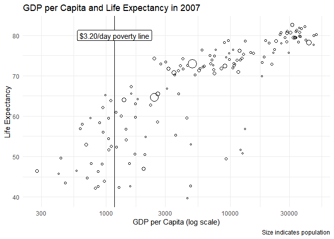

## Lines and Encirclings

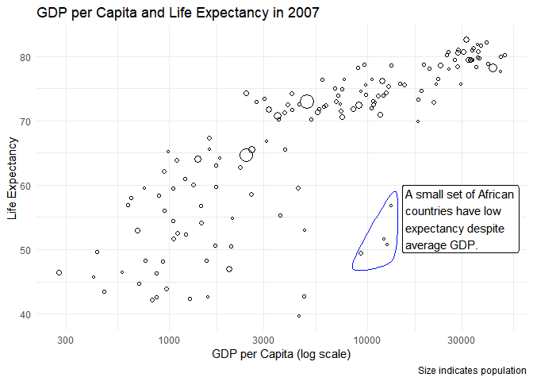

## Common Pitfalls

- Too many points
- Overlapping clusters of points
- Overlapping *points* (use jitter or heatmaps for discrete scatterplots!)
- Relying heavily on shape
- Unclear takeaway

## Common Pitfalls

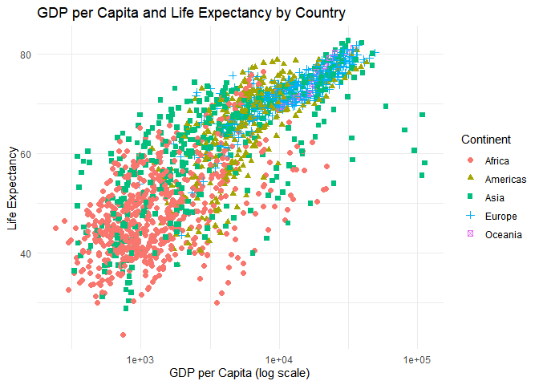

## Common Pitfalls

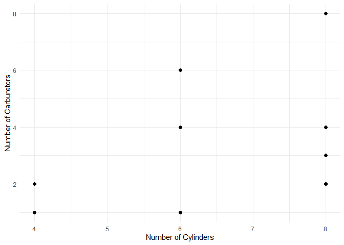

## Discrete Scatterplots - With Jitter

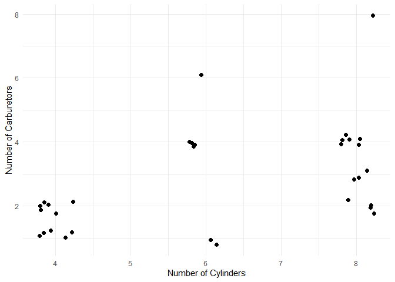

## Discrete or Busy Scatterplots - With Heat

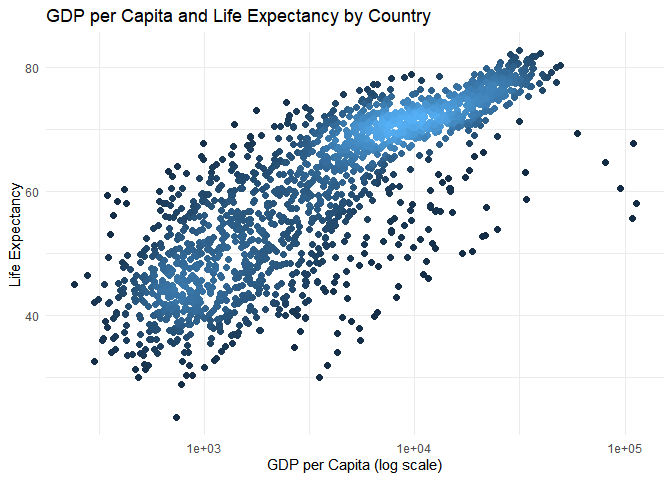

## Excel Scatterplots

- As long as you’re not going by-group, Excel scatterplots really are as easy as:
- X and Y column,
- Insert scatterplot
- Customize
- With more than one group, you need one set of columns per group, and add Legend Series in Select Data

## ggplot2 Scatterplots

- We’ve done plenty of `geom_point`s
- Conveniently, things stay just about the same if we have to change the geom
- `geom_text`, `geom_jitter` are in the **tidyverse**
- Outside we get text with `geom_text_repel` or `geom_label_repel` in **ggrepel** or `geom_pointdensity` in **ggpointdensity**
- The encircling is `geom_encircle` in **ggalt**

## Practice

- The data this time doesn’t require much processing
- https://vincentarelbundock.github.io/Rdatasets/csv/Stat2Data/Clothing.csv
- There’s a massive outlier though, remove that!
- Using variables Amount (amount of purchase), Recency (months since last purchase), and Dollar12 ($ spent in last year)
- Using `labels=scales::dollar` on the Amount axis.

## Replicate this Graph with ggplot2!

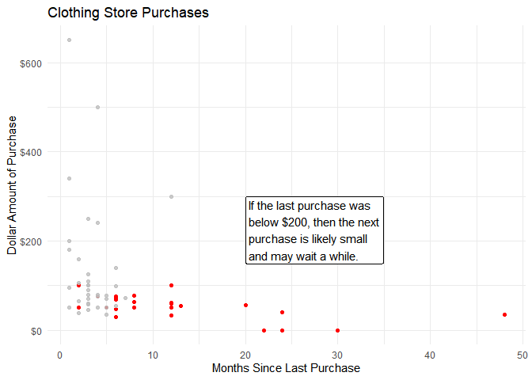

## Replicate This Graph!

```r
Clothing <- read_csv('https://vincentarelbundock.github.io/Rdatasets/csv/Stat2Data/Clothing.csv')
Clothing <- Clothing %>% slice(-60)
ggplot(Clothing,
       aes(x = Recency, y = Amount, color = Dollar12 >= 200,
           alpha = Dollar12 >= 200)) + geom_point() +
  labs(x = 'Months Since Last Purchase',
       y = "Dollar Amount of Purchase",
       title = 'Clothing Store Purchases') +
  scale_y_continuous(labels = scales::dollar)+
  scale_color_manual(values = c('red','gray'))+
  scale_alpha_manual(values = c(1,.8))+
  guides(color = FALSE, alpha = FALSE) +
  theme_minimal() +
  annotate(geom = 'label',x = 20, y =300, hjust = 0, vjust = 1,
           label = 'If the last purchase was\nbelow $200, then the next\npurchase is likely small\nand may wait a while.')
```

## Practice Graphing

- Now, working with Excel, replicate this graph:

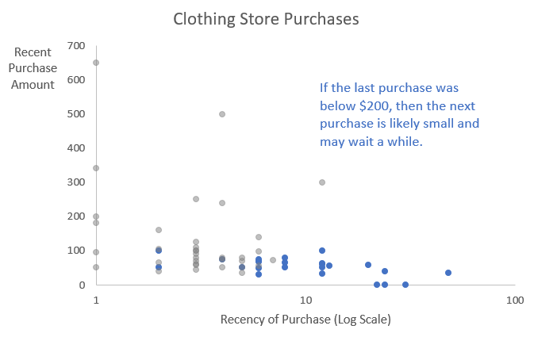

## Graphing

- Now with whatever time we have left, see if you can come up with another interesting graph! Excel or **ggplot2**